# Linear regression

## 1. Uni-variate linear regression

### 1.1. Least square estimate

One of the basic models to try while learning dependence between two real-valued variables $X$ and $Y$ is a uni-variate linear regression: $$ y=w x. $$

Admitting that the model's accuracy is not be absolute: $$ y=w x + \varepsilon,\hspace{5ex} (1.1) $$ where $\varepsilon$ is the model's error (often called noise or residual).

The objective is to learn $w$ given a training set of $\{(x_i, y_i), i=1..N\}$ providing the best possible fit for the model. The fit could be characterized by the errors of the model $$ \varepsilon_i=y_i-w x_i $$ and in particular by their sum of squares: $$ RSS(w)=\sum\limits_i \varepsilon_i^2=\sum\limits_i (y_i-w x_i)^2. \hspace{5ex} (1.2) $$ Minimizing such $RSS(w)\to min$ is called a least square approach. With respect to this criteria, regression becomes an optimization problem $$ \hat{w}=argmin_w RSS(w). \hspace{5ex} (1.3) $$ Luckily this problem has a precise analytic solution following from RSS function's shape and local extremum criteria: $$ RSS'(w)=0, $$ i.e. $$ 0=\frac{d\sum\limits_i (y_i-w x_i)^2}{dw}=\sum\limits_i\frac{d (y_i-w x_i)^2}{dw}=\sum\limits_i -2 x_i(y_i-w x_i), $$$$ 0=\sum\limits_i x_i y_i- w \sum\limits_i (x_i)^2, $$$$ \sum\limits_i x_i y_i = w \sum\limits_i (x_i)^2, $$$$ w=\frac{\sum\limits_i x_i y_i}{\sum\limits_i (x_i)^2}. \hspace{5ex} (1.4) $$ Thinking of $x_i$ and $y_i$ as the observations of random variables $X$ and $Y$ this can be rewritten as $$ w=\frac{E[XY]}{E[X^2]}. $$

### 1.2. Case of normalized variables

In case variables $x,y$ were normalized as $$ x:=\frac{x-E[X]}{\sigma[X]},\ y:=\frac{y-E[Y]}{\sigma[Y]} $$ in order to ensure zero averages $E[X]=E[Y]=0$ and unit standard deviations $\sigma[X]=\sigma[Y]=1$, the equation for $w$ could be rewritten as $$ w=\frac{E[XY]-E[X]E[Y]}{E[X^2]-E[X]^2}=\frac{E[XY]-E[X]E[Y]}{\sigma[X]^2}=\frac{E[XY]-E[X]E[Y]}{\sigma[X]\sigma[Y]}=corr(X,Y). $$ So in case of normalized $x,y$ a best fit univariate linear regression is provided by an equation $$ y=corr(X,Y)x $$

## 2. Multiple linear regression

### 2.1. Definition and parameter estimation

The linear model between single real-value regressor $x$ and output variable $y$ is expressed by $$ y=w_1 x + w_0 +\varepsilon. $$ $w_1$-slope coefficient, $w_0$ - intercept, $\varepsilon$ - random noise. In a more general case when $x$ is a real-valued $n \times 1$-vector $x=(x_1,x_2,...,x_n)^T$, the model could be easily generalized as $$ y=\sum\limits_j w_j x_j +\varepsilon (2.1) $$ or in a vector form $$ y=w^T x+\varepsilon, \hspace{5ex} (2.1') $$ where $w=(w_1,w_2,...,w_n)$ is also a $n \times 1$-vector. Notice that intercept is not specifically separated as it could be always introduced by adding a dummy variable $x^m\equiv 1$.

The probabilistic view on the model in the assumption that $\varepsilon\sim {\cal N}(0,\sigma^2)$ is $$ p(y|x,w,\sigma)={\cal N}(y|w^T x,\sigma^2). $$

Given a training set $X=\{(x_j^i), j=1..n, i=1..N\}$, $Y=\{(y^i), i=1..N\}$ (further also denote columns of $X$ as $X_j=\{(x_j^i), i=1..N\}$), the least square optimization criteria for inferring a vector of coefficients $w$ can be written as

$$ RSS(w)= \sum \limits_i \varepsilon_i^2= \sum \limits_i (y^i-w^T x^i)^2. \hspace{5ex} (2.2) $$

or in a matrix form: $$ RSS(w)=(Y-X w)^T(Y-X w). $$ Then finding an estimate $$ \hat{w}=argmin_w RSS(w) $$ can be done by solving the system (in a matrix form) $$ 0=\frac{\partial RSS(\hat{w})}{\partial w}=2X^T (Y-X \hat{w}). $$ Using matrix formalism the solution could be expressed as $$ \hat{w}=\left(X^T X\right )^{-1}X^T Y. \hspace{5ex} (2.3) $$ This assumes that $X^T X$ is non-singular. Otherwise we have a case of multicollinearity.

### 2.2. Case of orthogonal/uncorrelated regressors

Typically the resulting estimates for the coefficients $w_j$ of a multi-variate regression (2.1) are not the same as one could get from performing a series of uni-variate regressions $$ y\sim w_j x_j, j=1,2,...,n. \hspace{5ex} (2.4) $$ This is because the regressors might be correlated with each other and their impacts on the output variable could overlap and partly offset one another.

But in one special case of mutually orthogonal regressors, such that $$ x_i^T x_j=0, \hspace{5ex} (2.5) $$ for each $i\neq j$, multi-variate regression can be derived through a series of uni-variate regressions. This is because such a condition makes the matrix $X^T X$ in (2.3) diogonal and the solution effectively splits into a series of solutions (1.4) for the regressions (2.4). Condition (2.5) is called orthogonality of regressors.

In a particular case, when all the regressors are normalized as in 1.2, the orthogonality condition (2.5) is equivalent to the regressors being mutually uncorrelated. Then for normalized mutually uncorrelated regressors and a normalized output variable, a multi-variate regression (2.1) can be estimated as $$ y\sim\sum\limits_j corr(X_j,Y) x_j, \hspace{5ex} (2.6) $$ i.e. all the coefficients are estimated as correlations between the columns of observations for each regressor and the output variable. But remember, this is only the case when the regressors and the output variable were normalized and the regressors appeared to be mutually uncorrelated. Correlated regressors which we deal with in the most cases do not allow using the formulae (2.6).

### 2.3. Regression performance: R-squared

In the same way as for the bi-variate regression: $$ R^2=1-\frac{RSS}{\sum\limits_i (y_i-\overline{y})^2}=\frac{\sum\limits_i (\hat{y}_i-\overline{y})^2}{\sum\limits_i (y_i-\overline{y})^2}, $$ where $\overline{y}=\sum\limits_i y_i$ is the sample mean of observed values of responce variable, while $\hat{y}_i=w^T x_i$ is the predicted value of output variable as compared to the observed value of $y_i$ corresponding to $x=x_i$. This way $R^2$ is often interpreted as a fraction of responce variable's variance explained by linear model. $R^2=1$ is equivalent to $RSS=0$, i.e. the model fits the observations exactly, i.e. responce variable depends linearly on the explaining variables. On the other hand, $R^2=0$ means that the model always predicts the sample mean $\overline{y}$, i.e. explaining variables $x$ have no effect on responce variable $y$.

Least-square criteria is equivalent to maximizing $R^2$.

In case of a bi-variate regression with intercept $R^2=corr(Y,X)^2$, i.e. is a square of a correlation coefficient between observations of input and output variables.

## Case 1. Real estate prices in NYC

Consider the rolling sales data as in the LAB 2: the Department of Finance’s Rolling Sales files list properties that sold in the last twelve-month period in New York City for all tax classes. These files include:

- sale date
- address, ZIP Code, and tax borough, block, and lot (BBL)
- building type
- square footage
- price
- other characteristics

Focusing on Staten Island in 2019: **which characteristic of a house would be the best predictor for its price?**

```python
import pandas as pd
import numpy as np
import statsmodels.formula.api as smf
import matplotlib.pylab as plt
%matplotlib inline
import seaborn as sns
import math
import os
import urllib.request
import warnings
warnings.filterwarnings('ignore')
```

```python
#Read data
year = 2019
boro ='statenisland'
url = 'https://www1.nyc.gov/assets/finance/downloads/pdf/rolling_sales/annualized-sales/'+str(year)+'/'+str(year)+'_'+boro+'.xlsx'
urllib.request.urlretrieve(url,'Data/'+str(year)+boro+'.xlsx')

REStaten=pd.read_excel('Data/2019statenisland.xlsx',skiprows=4)

#Fix column names, excluding \n
REStaten.columns = [col.replace('\n','').replace(' ','_') for col in REStaten.columns]

REStaten.head()
```

|  | BOROUGH | NEIGHBORHOOD | BUILDING_CLASS_CATEGORY | TAX_CLASS_AS_OF_FINAL_ROLL_18/19 | BLOCK | LOT | EASE-MENT | BUILDING_CLASS_AS_OF_FINAL_ROLL_18/19 | ADDRESS | APARTMENT_NUMBER | ... | RESIDENTIAL_UNITS | COMMERCIAL_UNITS | TOTAL_UNITS | LAND_SQUARE_FEET | GROSS_SQUARE_FEET | YEAR_BUILT | TAX_CLASS_AT_TIME_OF_SALE | BUILDING_CLASS_AT_TIME_OF_SALE | SALE_PRICE | SALE_DATE |
| --- | --- | --- | --- | --- | --- | --- | --- | --- | --- | --- | --- | --- | --- | --- | --- | --- | --- | --- | --- | --- | --- |
| 0 | 5 | ANNADALE | 01 ONE FAMILY DWELLINGS | 1 | 5391 | 13 | NaN | A5 | 4716 AMBOY ROAD | NaN | ... | 1.0 | 0.0 | 1.0 | 1871.0 | 910.0 | 2002.0 | 1 | A5 | 0 | 2019-07-10 |
| 1 | 5 | ANNADALE | 01 ONE FAMILY DWELLINGS | 1 | 5393 | 29 | NaN | A1 | 21 FINGAL STREET | NaN | ... | 1.0 | 0.0 | 1.0 | 9000.0 | 3540.0 | 1985.0 | 1 | A1 | 1650000 | 2019-03-14 |
| 2 | 5 | ANNADALE | 01 ONE FAMILY DWELLINGS | 1 | 5395 | 23 | NaN | A1 | 525 SYCAMORE STREET | NaN | ... | 1.0 | 0.0 | 1.0 | 10000.0 | 2848.0 | 1980.0 | 1 | A1 | 775000 | 2019-12-13 |
| 3 | 5 | ANNADALE | 01 ONE FAMILY DWELLINGS | 1 | 5398 | 20 | NaN | A1 | 1468 ARDEN AVENUE | NaN | ... | 1.0 | 0.0 | 1.0 | 5000.0 | 2200.0 | 1940.0 | 1 | A1 | 685000 | 2019-04-15 |
| 4 | 5 | ANNADALE | 01 ONE FAMILY DWELLINGS | 1 | 5399 | 15 | NaN | A2 | 2 SANDBORN STREET | NaN | ... | 1.0 | 0.0 | 1.0 | 4845.0 | 880.0 | 1950.0 | 1 | A2 | 0 | 2019-01-24 |

5 rows × 21 columns

```python
#Subset dataframe by selecting columns we're going to use
selectedNames = ['BOROUGH','BLOCK','LOT', 'BUILDING_CLASS_CATEGORY', 'ADDRESS', 'ZIP_CODE',
                'GROSS_SQUARE_FEET', 'YEAR_BUILT','SALE_PRICE', 'SALE_DATE','RESIDENTIAL_UNITS','COMMERCIAL_UNITS','LAND_SQUARE_FEET']
REStaten = REStaten[selectedNames]

REStaten.head()
```

|  | BOROUGH | BLOCK | LOT | BUILDING_CLASS_CATEGORY | ADDRESS | ZIP_CODE | GROSS_SQUARE_FEET | YEAR_BUILT | SALE_PRICE | SALE_DATE | RESIDENTIAL_UNITS | COMMERCIAL_UNITS | LAND_SQUARE_FEET |
| --- | --- | --- | --- | --- | --- | --- | --- | --- | --- | --- | --- | --- | --- |
| 0 | 5 | 5391 | 13 | 01 ONE FAMILY DWELLINGS | 4716 AMBOY ROAD | 10312.0 | 910.0 | 2002.0 | 0 | 2019-07-10 | 1.0 | 0.0 | 1871.0 |
| 1 | 5 | 5393 | 29 | 01 ONE FAMILY DWELLINGS | 21 FINGAL STREET | 10312.0 | 3540.0 | 1985.0 | 1650000 | 2019-03-14 | 1.0 | 0.0 | 9000.0 |
| 2 | 5 | 5395 | 23 | 01 ONE FAMILY DWELLINGS | 525 SYCAMORE STREET | 10312.0 | 2848.0 | 1980.0 | 775000 | 2019-12-13 | 1.0 | 0.0 | 10000.0 |
| 3 | 5 | 5398 | 20 | 01 ONE FAMILY DWELLINGS | 1468 ARDEN AVENUE | 10312.0 | 2200.0 | 1940.0 | 685000 | 2019-04-15 | 1.0 | 0.0 | 5000.0 |
| 4 | 5 | 5399 | 15 | 01 ONE FAMILY DWELLINGS | 2 SANDBORN STREET | 10312.0 | 880.0 | 1950.0 | 0 | 2019-01-24 | 1.0 | 0.0 | 4845.0 |

```python
#Get summary statistics
REStaten.describe()
```

|  | BOROUGH | BLOCK | LOT | ZIP_CODE | GROSS_SQUARE_FEET | YEAR_BUILT | SALE_PRICE | RESIDENTIAL_UNITS | COMMERCIAL_UNITS | LAND_SQUARE_FEET |
| --- | --- | --- | --- | --- | --- | --- | --- | --- | --- | --- |
| count | 8371.0 | 8371.000000 | 8371.000000 | 8365.000000 | 8280.000000 | 7856.000000 | 8.371000e+03 | 8280.000000 | 8280.000000 | 8.280000e+03 |
| mean | 5.0 | 3383.670649 | 183.094612 | 10307.971907 | 1605.700725 | 1968.794297 | 4.157112e+05 | 1.194807 | 0.044928 | 4.812098e+03 |
| std | 0.0 | 2378.865466 | 414.758348 | 4.149530 | 2416.613354 | 31.534770 | 1.291787e+06 | 0.743192 | 0.304432 | 3.112026e+04 |
| min | 5.0 | 1.000000 | 1.000000 | 10301.000000 | 0.000000 | 1800.000000 | 0.000000e+00 | 0.000000 | 0.000000 | 0.000000e+00 |
| 25% | 5.0 | 1092.000000 | 24.000000 | 10305.000000 | 1020.000000 | 1950.000000 | 0.000000e+00 | 1.000000 | 0.000000 | 2.191500e+03 |
| 50% | 5.0 | 3246.000000 | 55.000000 | 10308.000000 | 1440.000000 | 1975.000000 | 3.950000e+05 | 1.000000 | 0.000000 | 3.420000e+03 |
| 75% | 5.0 | 5458.000000 | 125.000000 | 10312.000000 | 2025.000000 | 1991.000000 | 5.990000e+05 | 1.000000 | 0.000000 | 4.810000e+03 |
| max | 5.0 | 8050.000000 | 5344.000000 | 10314.000000 | 108275.000000 | 2019.000000 | 9.272502e+07 | 19.000000 | 8.000000 | 2.549173e+06 |

```python
#Get unique categories of buildings
REStaten['BUILDING_CLASS_CATEGORY'].unique()
```

```
array(['01 ONE FAMILY DWELLINGS', '02 TWO FAMILY DWELLINGS',
       '05 TAX CLASS 1 VACANT LAND', '21 OFFICE BUILDINGS',
       '22 STORE BUILDINGS', '29 COMMERCIAL GARAGES',
       '31 COMMERCIAL VACANT LAND', '04 TAX CLASS 1 CONDOS',
       '06 TAX CLASS 1 - OTHER', '14 RENTALS - 4-10 UNIT',
       '33 EDUCATIONAL FACILITIES', '10 COOPS - ELEVATOR APARTMENTS',
       '13 CONDOS - ELEVATOR APARTMENTS', '43 CONDO OFFICE BUILDINGS',
       '30 WAREHOUSES', '07 RENTALS - WALKUP APARTMENTS',
       '32 HOSPITAL AND HEALTH FACILITIES', '03 THREE FAMILY DWELLINGS',
       '09 COOPS - WALKUP APARTMENTS', '12 CONDOS - WALKUP APARTMENTS',
       '37 RELIGIOUS FACILITIES', '27 FACTORIES',
       '41 TAX CLASS 4 - OTHER', '44 CONDO PARKING',
       '15 CONDOS - 2-10 UNIT RESIDENTIAL',
       '16 CONDOS - 2-10 UNIT WITH COMMERCIAL UNIT',
       '35 INDOOR PUBLIC AND CULTURAL FACILITIES',
       '08 RENTALS - ELEVATOR APARTMENTS',
       '36 OUTDOOR RECREATIONAL FACILITIES'], dtype=object)
```

```python
#Sanity filtering (and take only those with residential units)
REStaten = REStaten.loc[(REStaten['ZIP_CODE'] > 0) & (REStaten['GROSS_SQUARE_FEET'] > 0) & (REStaten['YEAR_BUILT'] > 0) & (REStaten['SALE_PRICE'] > 0)]
REStaten = REStaten.loc[(REStaten['YEAR_BUILT'] >= 1850) & (REStaten['GROSS_SQUARE_FEET'] >=300) & (REStaten['GROSS_SQUARE_FEET'] <1e4) & (REStaten['LAND_SQUARE_FEET'] >=300)
              & (REStaten['SALE_PRICE'] >= 1e4) & (REStaten['SALE_PRICE'] <= 3e6) & (REStaten['RESIDENTIAL_UNITS']>0)]

#Take only one-three family houses
REStaten_ = REStaten[REStaten['BUILDING_CLASS_CATEGORY'].apply(lambda x: x[:2]).astype('int')<=3].copy()
```

```python
REStaten_['BUILDING_CLASS_CATEGORY'].unique()
```

```
array(['01 ONE FAMILY DWELLINGS', '02 TWO FAMILY DWELLINGS',
       '03 THREE FAMILY DWELLINGS'], dtype=object)
```

```python
REStaten_.shape
```

```
(4416, 13)
```

```python
REStaten_.describe()
```

|  | BOROUGH | BLOCK | LOT | ZIP_CODE | GROSS_SQUARE_FEET | YEAR_BUILT | SALE_PRICE | RESIDENTIAL_UNITS | COMMERCIAL_UNITS | LAND_SQUARE_FEET |
| --- | --- | --- | --- | --- | --- | --- | --- | --- | --- | --- |
| count | 4416.0 | 4416.000000 | 4416.000000 | 4416.000000 | 4416.000000 | 4416.000000 | 4.416000e+03 | 4416.000000 | 4416.000000 | 4416.000000 |
| mean | 5.0 | 3379.954031 | 81.978261 | 10307.974411 | 1709.162364 | 1968.017889 | 5.826647e+05 | 1.281476 | 0.005208 | 3932.816803 |
| std | 0.0 | 2385.493555 | 95.660983 | 4.096904 | 753.904671 | 32.913716 | 2.337312e+05 | 0.471888 | 0.075069 | 2787.484429 |
| min | 5.0 | 14.000000 | 1.000000 | 10301.000000 | 400.000000 | 1865.000000 | 1.000000e+04 | 1.000000 | 0.000000 | 353.000000 |
| 25% | 5.0 | 1084.000000 | 23.000000 | 10305.000000 | 1216.750000 | 1945.000000 | 4.440990e+05 | 1.000000 | 0.000000 | 2400.000000 |
| 50% | 5.0 | 3287.500000 | 50.000000 | 10308.000000 | 1516.000000 | 1970.000000 | 5.550000e+05 | 1.000000 | 0.000000 | 3500.000000 |
| 75% | 5.0 | 5487.000000 | 103.000000 | 10312.000000 | 2050.000000 | 1995.000000 | 6.850000e+05 | 2.000000 | 0.000000 | 4600.000000 |
| max | 5.0 | 8050.000000 | 853.000000 | 10314.000000 | 9375.000000 | 2019.000000 | 2.575000e+06 | 4.000000 | 2.000000 | 45444.000000 |

```
array([[<AxesSubplot:title={'center':'RESIDENTIAL_UNITS'}>]], dtype=object)
```

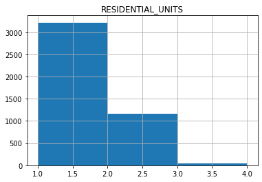

```python
#Stats on the number of residential units
REStaten_.hist('RESIDENTIAL_UNITS', bins=3)
```

```python
#Run correlation analysis
REStaten_[['YEAR_BUILT','RESIDENTIAL_UNITS','COMMERCIAL_UNITS','GROSS_SQUARE_FEET','LAND_SQUARE_FEET','SALE_PRICE']].corr()
```

|  | YEAR_BUILT | RESIDENTIAL_UNITS | COMMERCIAL_UNITS | GROSS_SQUARE_FEET | LAND_SQUARE_FEET | SALE_PRICE |
| --- | --- | --- | --- | --- | --- | --- |
| YEAR_BUILT | 1.000000 | -0.009658 | -0.054582 | 0.141006 | -0.220481 | 0.206584 |
| RESIDENTIAL_UNITS | -0.009658 | 1.000000 | -0.009424 | 0.383982 | 0.110894 | 0.245418 |
| COMMERCIAL_UNITS | -0.054582 | -0.009424 | 1.000000 | 0.067633 | 0.067733 | 0.005392 |
| GROSS_SQUARE_FEET | 0.141006 | 0.383982 | 0.067633 | 1.000000 | 0.464357 | 0.640454 |
| LAND_SQUARE_FEET | -0.220481 | 0.110894 | 0.067733 | 0.464357 | 1.000000 | 0.521999 |
| SALE_PRICE | 0.206584 | 0.245418 | 0.005392 | 0.640454 | 0.521999 | 1.000000 |

Size and land area appear to demonstrate the strongest correlations trailed by the number of residential units.

Perform a uni-variate linear regression on the feature showing the strongest correlation: the size.

```python
from sklearn.linear_model import LinearRegression

#Fit the regression without intercept
lm = LinearRegression(fit_intercept=False).fit(REStaten_[['GROSS_SQUARE_FEET']], REStaten_['SALE_PRICE'])
lm.coef_
```

```
array([317.72592299])
```

```python
#Fit regression with intercept
lm = LinearRegression(fit_intercept=True).fit(REStaten_[['GROSS_SQUARE_FEET']], REStaten_['SALE_PRICE'])
lm.coef_, lm.intercept_
```

```
(array([198.55835005]), 243296.25750452263)
```

```python
#Print full output
lm = smf.ols(formula='SALE_PRICE~GROSS_SQUARE_FEET', data = REStaten_).fit()

print(lm.summary())
```

```
                            OLS Regression Results
==============================================================================
Dep. Variable:             SALE_PRICE   R-squared:                       0.410
Model:                            OLS   Adj. R-squared:                  0.410
Method:                 Least Squares   F-statistic:                     3070.
Date:                Sun, 22 May 2022   Prob (F-statistic):               0.00
Time:                        16:45:38   Log-Likelihood:                -59690.
No. Observations:                4416   AIC:                         1.194e+05
Df Residuals:                    4414   BIC:                         1.194e+05
Df Model:                           1
Covariance Type:            nonrobust
=====================================================================================
                        coef    std err          t      P>|t|      [0.025      0.975]
-------------------------------------------------------------------------------------
Intercept          2.433e+05   6694.585     36.342      0.000     2.3e+05    2.56e+05
GROSS_SQUARE_FEET   198.5584      3.584     55.404      0.000     191.532     205.584
==============================================================================
Omnibus:                      462.623   Durbin-Watson:                   1.425
Prob(Omnibus):                  0.000   Jarque-Bera (JB):             3749.138
Skew:                           0.117   Prob(JB):                         0.00
Kurtosis:                       7.508   Cond. No.                     4.63e+03
==============================================================================

Notes:
[1] Standard Errors assume that the covariance matrix of the errors is correctly specified.
[2] The condition number is large, 4.63e+03. This might indicate that there are
strong multicollinearity or other numerical problems.
```

Now standardize the sale_price and gross_square_feet by subtracting averages and dividing by standard deviation $$ X^*:=(X-E[X])/\sigma(X) $$ Repeat the regression. Compare the regression coefficient against the correlation between sale_price and gross_square_feet. Do you find anything interesting here? Does the slope coefficient remind you something?

```python
REStaten_['PRICE_stand']=(REStaten_['SALE_PRICE']-REStaten_['SALE_PRICE'].mean())/REStaten_['SALE_PRICE'].std()
REStaten_['SIZE_stand']=(REStaten_['GROSS_SQUARE_FEET']-REStaten_['GROSS_SQUARE_FEET'].mean())/REStaten_['GROSS_SQUARE_FEET'].std()

lm = smf.ols(formula='PRICE_stand~SIZE_stand-1', data = REStaten_).fit()
print(lm.summary())
```

```
                                 OLS Regression Results
=======================================================================================
Dep. Variable:            PRICE_stand   R-squared (uncentered):                   0.410
Model:                            OLS   Adj. R-squared (uncentered):              0.410
Method:                 Least Squares   F-statistic:                              3070.
Date:                Sun, 22 May 2022   Prob (F-statistic):                        0.00
Time:                        16:45:38   Log-Likelihood:                         -5099.8
No. Observations:                4416   AIC:                                  1.020e+04
Df Residuals:                    4415   BIC:                                  1.021e+04
Df Model:                           1
Covariance Type:            nonrobust
==============================================================================
                 coef    std err          t      P>|t|      [0.025      0.975]
------------------------------------------------------------------------------
SIZE_stand     0.6405      0.012     55.411      0.000       0.618       0.663
==============================================================================
Omnibus:                      462.623   Durbin-Watson:                   1.425
Prob(Omnibus):                  0.000   Jarque-Bera (JB):             3749.138
Skew:                           0.117   Prob(JB):                         0.00
Kurtosis:                       7.508   Cond. No.                         1.00
==============================================================================

Notes:
[1] R² is computed without centering (uncentered) since the model does not contain a constant.
[2] Standard Errors assume that the covariance matrix of the errors is correctly specified.
```

As we see the coefficient is exacltly the correlation coeffient between the Price and Size

```python
corrXY = np.corrcoef(REStaten_['SALE_PRICE'],REStaten_['GROSS_SQUARE_FEET'])[0,1]
corrXY
```

```
0.6404539846221196
```

And the R-squared is exactly the square of the correlation coefficient

```python
corrXY**2
```

```
0.41018130641835016
```

```python
lm.rsquared
```

```
0.41018130641835027
```

```python
#Perform regression on 100 subsamples
np.random.seed(2019)
W=[]
for i in range(0,100):
    df=REStaten_.sample(frac=0.7)
    lm = smf.ols(formula='SALE_PRICE~GROSS_SQUARE_FEET-1', data = df).fit()
    W+=[lm.params.GROSS_SQUARE_FEET]
```

```python
#Report mean and standard deviations of the resulting slope coefficients
np.array(W).mean()
```

```
317.64825558819604
```

```python
np.array(W).std()
```

```
1.8040727106985592
```

Visualizations might further give an idea on how does the regression perform

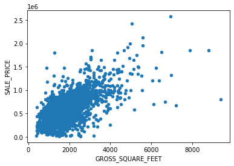

```python
#Visualize the data
REStaten_.plot(x='GROSS_SQUARE_FEET',y='SALE_PRICE',kind='scatter')
```

```python
#Obtain values predicted by the regression
lm = smf.ols(formula='SALE_PRICE~GROSS_SQUARE_FEET', data = REStaten_).fit()
REStaten_['predicted_price']=lm.predict()
```

```python
REStaten_[['SALE_PRICE','predicted_price']].head()
```

|  | SALE_PRICE | predicted_price |
| --- | --- | --- |
| 1 | 1650000 | 946192.816664 |
| 2 | 775000 | 808790.438433 |
| 3 | 685000 | 680124.627604 |
| 6 | 620000 | 393406.370139 |
| 8 | 1221900 | 799259.637631 |

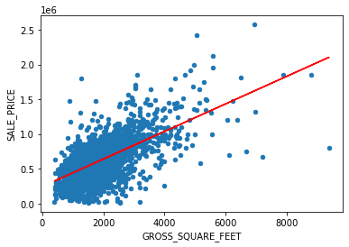

```python
#Add the prediction line
fig, ax = plt.subplots()
REStaten_.plot(ax=ax,kind='scatter',x='GROSS_SQUARE_FEET', y='SALE_PRICE')
ax.plot(REStaten_['GROSS_SQUARE_FEET'],REStaten_['predicted_price'],'r-')
```

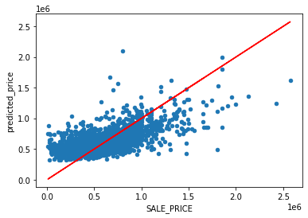

```python
#Another way visualize: actual values vs predicted values
fig, ax = plt.subplots()
REStaten_.plot(ax=ax,kind='scatter',x='SALE_PRICE', y='predicted_price')
ax.plot(REStaten_['SALE_PRICE'],REStaten_['SALE_PRICE'],'r-')
```

### Homework task 1. Perform regressions on the remaining regressors:

LAND_SQUARE_FEET,YEAR_BUILT,RESIDENTIAL_UNITS,COMMERCIAL_UNITS, with intercept. Visualize the regression fit

Report results (together with those for GROSS_SQ_FEET) in a data frame with the following columns: slope | intercept | R2, having regressors as index. R-squared could be obtained through lm.rsquared

```python
regressors=['GROSS_SQUARE_FEET','LAND_SQUARE_FEET','YEAR_BUILT','RESIDENTIAL_UNITS','COMMERCIAL_UNITS']
```

```python
res=[]
for r in regressors:
    lm=smf.ols(formula='SALE_PRICE~'+r, data = df).fit();
    res+=[[lm.params[r], lm.params.Intercept, lm.rsquared]]
pd.DataFrame(res,columns=['Slope','Intercept','R2'],index=regressors)
```

|  | Slope | Intercept | R2 |
| --- | --- | --- | --- |
| GROSS_SQUARE_FEET | 189.034454 | 2.563476e+05 | 0.379975 |
| LAND_SQUARE_FEET | 43.585850 | 4.087957e+05 | 0.277242 |
| YEAR_BUILT | 1423.104153 | -2.223549e+06 | 0.042822 |
| RESIDENTIAL_UNITS | 123826.615811 | 4.191294e+05 | 0.065865 |
| COMMERCIAL_UNITS | -11904.445071 | 5.770250e+05 | 0.000015 |

## Multi-variate regression case

Now try multivariate regression on GROSS_SQUARE_FEET+LAND_SQUARE_FEET+YEAR_BUILT together

```python
lm = smf.ols(formula='SALE_PRICE~GROSS_SQUARE_FEET+LAND_SQUARE_FEET+YEAR_BUILT', data = REStaten_).fit()
print(lm.summary())
```

```
                            OLS Regression Results
==============================================================================
Dep. Variable:             SALE_PRICE   R-squared:                       0.519
Model:                            OLS   Adj. R-squared:                  0.519
Method:                 Least Squares   F-statistic:                     1589.
Date:                Sun, 22 May 2022   Prob (F-statistic):               0.00
Time:                        16:45:39   Log-Likelihood:                -59238.
No. Observations:                4416   AIC:                         1.185e+05
Df Residuals:                    4412   BIC:                         1.185e+05
Df Model:                           3
Covariance Type:            nonrobust
=====================================================================================
                        coef    std err          t      P>|t|      [0.025      0.975]
-------------------------------------------------------------------------------------
Intercept         -2.933e+06   1.55e+05    -18.859      0.000   -3.24e+06   -2.63e+06
GROSS_SQUARE_FEET   135.5709      3.808     35.601      0.000     128.105     143.037
LAND_SQUARE_FEET     30.9260      1.045     29.584      0.000      28.877      32.975
YEAR_BUILT         1606.6190     79.201     20.285      0.000    1451.346    1761.892
==============================================================================
Omnibus:                      555.642   Durbin-Watson:                   1.568
Prob(Omnibus):                  0.000   Jarque-Bera (JB):             4478.589
Skew:                          -0.322   Prob(JB):                         0.00
Kurtosis:                       7.891   Cond. No.                     3.42e+05
==============================================================================

Notes:
[1] Standard Errors assume that the covariance matrix of the errors is correctly specified.
[2] The condition number is large, 3.42e+05. This might indicate that there are
strong multicollinearity or other numerical problems.
```

Now try multivariate regression on RESIDENTIAL_UNITS+COMMERCIAL_UNITS together

```python
lm = smf.ols(formula='SALE_PRICE~RESIDENTIAL_UNITS+COMMERCIAL_UNITS', data = REStaten_).fit()
print(lm.summary())
```

```
                            OLS Regression Results
==============================================================================
Dep. Variable:             SALE_PRICE   R-squared:                       0.060
Model:                            OLS   Adj. R-squared:                  0.060
Method:                 Least Squares   F-statistic:                     141.6
Date:                Sun, 22 May 2022   Prob (F-statistic):           2.58e-60
Time:                        16:45:39   Log-Likelihood:                -60719.
No. Observations:                4416   AIC:                         1.214e+05
Df Residuals:                    4413   BIC:                         1.215e+05
Df Model:                           2
Covariance Type:            nonrobust
=====================================================================================
                        coef    std err          t      P>|t|      [0.025      0.975]
-------------------------------------------------------------------------------------
Intercept          4.267e+05   9875.494     43.210      0.000    4.07e+05    4.46e+05
RESIDENTIAL_UNITS  1.216e+05   7228.148     16.822      0.000    1.07e+05    1.36e+05
COMMERCIAL_UNITS   2.399e+04   4.54e+04      0.528      0.597   -6.51e+04    1.13e+05
==============================================================================
Omnibus:                     1587.250   Durbin-Watson:                   1.170
Prob(Omnibus):                  0.000   Jarque-Bera (JB):            11725.742
Skew:                           1.520   Prob(JB):                         0.00
Kurtosis:                      10.381   Cond. No.                         22.2
==============================================================================

Notes:
[1] Standard Errors assume that the covariance matrix of the errors is correctly specified.
```

And now combine all the variables together

```python
lm = smf.ols(formula='SALE_PRICE~GROSS_SQUARE_FEET+LAND_SQUARE_FEET+YEAR_BUILT+RESIDENTIAL_UNITS+COMMERCIAL_UNITS', data = REStaten_).fit()
print(lm.summary())
```

```
                            OLS Regression Results
==============================================================================
Dep. Variable:             SALE_PRICE   R-squared:                       0.522
Model:                            OLS   Adj. R-squared:                  0.522
Method:                 Least Squares   F-statistic:                     964.6
Date:                Sun, 22 May 2022   Prob (F-statistic):               0.00
Time:                        16:45:39   Log-Likelihood:                -59224.
No. Observations:                4416   AIC:                         1.185e+05
Df Residuals:                    4410   BIC:                         1.185e+05
Df Model:                           5
Covariance Type:            nonrobust
=====================================================================================
                        coef    std err          t      P>|t|      [0.025      0.975]
-------------------------------------------------------------------------------------
Intercept         -2.987e+06   1.57e+05    -19.061      0.000   -3.29e+06   -2.68e+06
GROSS_SQUARE_FEET   129.9657      4.131     31.460      0.000     121.867     138.065
LAND_SQUARE_FEET     31.4609      1.049     29.992      0.000      29.404      33.517
YEAR_BUILT         1624.0300     79.523     20.422      0.000    1468.125    1779.935
RESIDENTIAL_UNITS  2.215e+04   5636.248      3.930      0.000    1.11e+04    3.32e+04
COMMERCIAL_UNITS  -1.104e+05   3.26e+04     -3.390      0.001   -1.74e+05   -4.66e+04
==============================================================================
Omnibus:                      547.931   Durbin-Watson:                   1.570
Prob(Omnibus):                  0.000   Jarque-Bera (JB):             4618.621
Skew:                          -0.287   Prob(JB):                         0.00
Kurtosis:                       7.977   Cond. No.                     3.45e+05
==============================================================================

Notes:
[1] Standard Errors assume that the covariance matrix of the errors is correctly specified.
[2] The condition number is large, 3.45e+05. This might indicate that there are
strong multicollinearity or other numerical problems.
```

## Homework task 2

Now consider houses with different numbers of residential units: repeat the SALE_PRICE~GROSS_SQUARE_FEET+LAND_SQUARE_FEET+YEAR_BUILT regression for houses with RESIDENTIAL_UNITS==1,2 and "3 or above", COMMERCIAL_UNITS==0. Summarize the number of samples in each category, coefficients and r-squared values of the corresponding regressions in a dataframe with the following columns: samples,GROSS_SQUARE_FEET_coef,LAND_SQUARE_FEET_coef,YEAR_BUILT,coef,Intercept,R2. Make the number of RESIDENTIAL_UNITS (1,2 or '3+') an index

```python
res=[];
for r in range(1,4):
    if r<3:
        df=REStaten_.loc[(REStaten_.RESIDENTIAL_UNITS==r)&(REStaten_.COMMERCIAL_UNITS==0)]
    else:
        df=REStaten_.loc[(REStaten_.RESIDENTIAL_UNITS>=r)&(REStaten_.COMMERCIAL_UNITS==0)]
    lm=smf.ols(formula='SALE_PRICE~GROSS_SQUARE_FEET+LAND_SQUARE_FEET+YEAR_BUILT', data = df).fit();
    res+=[[df.shape[0],lm.params.GROSS_SQUARE_FEET,lm.params.LAND_SQUARE_FEET, lm.params.YEAR_BUILT,lm.params.Intercept, lm.rsquared]]
pd.DataFrame(res,columns=['samples','GROSS_SQUARE_FEET_coef','LAND_SQUARE_FEET_coef','YEAR_BUILT_coef','Intercept','R2'],index=['1','2','3+'])
```

|  | samples | GROSS_SQUARE_FEET_coef | LAND_SQUARE_FEET_coef | YEAR_BUILT_coef | Intercept | R2 |
| --- | --- | --- | --- | --- | --- | --- |
| 1 | 3200 | 139.387163 | 30.558815 | 1134.016234 | -2.012218e+06 | 0.526892 |
| 2 | 1151 | 113.883675 | 31.076155 | 2517.044042 | -4.662861e+06 | 0.433946 |
| 3+ | 43 | 29.529114 | 51.992945 | 2381.431181 | -4.258056e+06 | 0.529637 |

## Urban activity data

Many of your Urban Informatics projects will deal with urban population. Let's take a closer look at how it can be defined and how is it distributed in space.

Specifically lets focus on the following questions:

- **Is the residential population distribution representative for urban dynamics in bulk?**
- **Can adding daytime population help?**

Daytime population is based on LEHD commute data: https://lehd.ces.census.gov/data/

The activity dataset includes Citibike trips, 311 service requests, Mobile device connections, subway entries, taxi trips, Twitter activity aggregated on the level of taxi zones. More details on those data can be found in the preprint [Zhu, E., Khan, M., Kats, P., Bamne, S. S., & Sobolevsky, S. (2018). Digital urban sensing: A multi-layered approach. arXiv preprint arXiv:1809.01280] completed together with CUSP students.

```python
#Upload the main dataset
SMdata=pd.read_csv("https://raw.githubusercontent.com/CUSP2020PUI/Data/master/Socio-mobility.csv",index_col=0)

#Rename some of the columns for the sake of consistency and also to replace '-'
SMdata.rename(columns={'mobile-device_spatial':'mobile','citibike_spatial':'citibike','sr311_spatial':'sr311','subway_spatial':'subway','taxi_spatial':'taxi','twitter_spatial':'twitter'},inplace=True)

#Also upload two other datasets from the last class - residential and working population
LEHDW=pd.read_csv("https://raw.githubusercontent.com/CUSP2020PUI/Data/master/LEHD-work.csv",index_col=0)
LEHDR=pd.read_csv("https://raw.githubusercontent.com/CUSP2020PUI/Data/master/LEHD-resident.csv",index_col=0)

#Merge the datasets (inner merge on index - taxi zone number); take only the columns to use later
SMdata=SMdata[['population','mobile','citibike','sr311','subway','taxi','twitter']].merge(LEHDW[['total']].rename(columns={'total':'working'}), on=None, left_index=True, right_index=True, how='inner')
SMdata=SMdata.merge(LEHDR[['total']].rename(columns={'total':'residential'}), on=None, left_index=True, right_index=True, how='inner')

SMdata.head()
```

| tz | population | mobile | citibike | sr311 | subway | taxi | twitter | working | residential |
| --- | --- | --- | --- | --- | --- | --- | --- | --- | --- |
| 3 | 32450.0 | 109300 | 0 | 700 | 225527.5 | 31960 | 480 | 4989 | 11398 |
| 4 | 27571.0 | 179644 | 31545 | 399 | 0.0 | 178515 | 85 | 2717 | 12318 |
| 5 | 26482.0 | 56271 | 0 | 490 | 0.0 | 3667 | 40 | 1191 | 10751 |
| 6 | 15896.0 | 147674 | 0 | 255 | 0.0 | 7456 | 88 | 2495 | 6729 |
| 7 | 77252.0 | 508255 | 0 | 1389 | 3336898.0 | 362180 | 2294 | 17223 | 43048 |

```python
#Get pair-wise column correlations
SMdata.corr()
```

|  | population | mobile | citibike | sr311 | subway | taxi | twitter | working | residential |
| --- | --- | --- | --- | --- | --- | --- | --- | --- | --- |
| population | 1.000000 | 0.670248 | -0.210465 | 0.877397 | -0.042691 | -0.059860 | -0.028276 | -0.099852 | 0.969425 |
| mobile | 0.670248 | 1.000000 | -0.066319 | 0.607098 | 0.219016 | 0.144768 | 0.214191 | 0.175743 | 0.646672 |
| citibike | -0.210465 | -0.066319 | 1.000000 | -0.183276 | 0.486907 | 0.748109 | 0.372861 | 0.513090 | -0.102762 |
| sr311 | 0.877397 | 0.607098 | -0.183276 | 1.000000 | -0.010677 | -0.026607 | 0.066799 | -0.049597 | 0.865145 |
| subway | -0.042691 | 0.219016 | 0.486907 | -0.010677 | 1.000000 | 0.630203 | 0.496341 | 0.703456 | 0.020381 |
| taxi | -0.059860 | 0.144768 | 0.748109 | -0.026607 | 0.630203 | 1.000000 | 0.556061 | 0.720043 | 0.053496 |
| twitter | -0.028276 | 0.214191 | 0.372861 | 0.066799 | 0.496341 | 0.556061 | 1.000000 | 0.626458 | 0.017787 |
| working | -0.099852 | 0.175743 | 0.513090 | -0.049597 | 0.703456 | 0.720043 | 0.626458 | 1.000000 | -0.040786 |
| residential | 0.969425 | 0.646672 | -0.102762 | 0.865145 | 0.020381 | 0.053496 | 0.017787 | -0.040786 | 1.000000 |

But notice that some activities are not defined for the entire city. It would be more appropriate to correlate only where activity is defined

```python
#Auxiliary function to compute correlations between columns where both have data
def NZPopCorr(col1,col2):
    ind=(SMdata[col1]>0)&(SMdata[col2]>0)
    return np.corrcoef(SMdata[col1][ind],SMdata[col2][ind])[0][1]

#Output a table with correlations between activities and population counts
PL=['population','residential','working']
ML=['taxi','subway','citibike','twitter','mobile','sr311']
pd.DataFrame([[NZPopCorr(M,P) for P in PL] for M in ML],columns=PL,index=ML)
```

|  | population | residential | working |
| --- | --- | --- | --- |
| taxi | -0.064720 | 0.049633 | 0.719559 |
| subway | -0.232504 | -0.141712 | 0.720643 |
| citibike | -0.126996 | 0.011210 | 0.319030 |
| twitter | -0.032551 | 0.017787 | 0.626458 |
| mobile | 0.676604 | 0.646672 | 0.175743 |
| sr311 | 0.869460 | 0.863358 | -0.056116 |

Now we can implement a regression for urban activities a) vs population and b) vs LEHD residential and working population taken as separate regressors

Implement these regressions a) and b) for taxi and 311. No intercept

```python
lm = smf.ols(formula='taxi~working+residential-1', data = SMdata.loc[SMdata.taxi>0]).fit()
print(lm.summary())
```

```
                                 OLS Regression Results
=======================================================================================
Dep. Variable:                   taxi   R-squared (uncentered):                   0.688
Model:                            OLS   Adj. R-squared (uncentered):              0.685
Method:                 Least Squares   F-statistic:                              279.9
Date:                Sun, 22 May 2022   Prob (F-statistic):                    6.01e-65
Time:                        16:45:40   Log-Likelihood:                         -3426.8
No. Observations:                 256   AIC:                                      6858.
Df Residuals:                     254   BIC:                                      6865.
Df Model:                           2
Covariance Type:            nonrobust
===============================================================================
                  coef    std err          t      P>|t|      [0.025      0.975]
-------------------------------------------------------------------------------
working         6.6430      0.357     18.591      0.000       5.939       7.347
residential     3.5450      0.644      5.508      0.000       2.277       4.813
==============================================================================
Omnibus:                       97.957   Durbin-Watson:                   1.665
Prob(Omnibus):                  0.000   Jarque-Bera (JB):              342.882
Skew:                           1.620   Prob(JB):                     3.50e-75
Kurtosis:                       7.652   Cond. No.                         2.12
==============================================================================

Notes:
[1] R² is computed without centering (uncentered) since the model does not contain a constant.
[2] Standard Errors assume that the covariance matrix of the errors is correctly specified.
```

```python
lm = smf.ols(formula='sr311~working+residential-1', data = SMdata.loc[SMdata.sr311>0]).fit()
print(lm.summary())
```

```
                                 OLS Regression Results
=======================================================================================
Dep. Variable:                  sr311   R-squared (uncentered):                   0.901
Model:                            OLS   Adj. R-squared (uncentered):              0.901
Method:                 Least Squares   F-statistic:                              1156.
Date:                Sun, 22 May 2022   Prob (F-statistic):                   5.67e-128
Time:                        16:45:40   Log-Likelihood:                         -1807.3
No. Observations:                 255   AIC:                                      3619.
Df Residuals:                     253   BIC:                                      3626.
Df Model:                           2
Covariance Type:            nonrobust
===============================================================================
                  coef    std err          t      P>|t|      [0.025      0.975]
-------------------------------------------------------------------------------
working        -0.0003      0.001     -0.480      0.631      -0.002       0.001
residential     0.0519      0.001     43.862      0.000       0.050       0.054
==============================================================================
Omnibus:                       14.915   Durbin-Watson:                   1.803
Prob(Omnibus):                  0.001   Jarque-Bera (JB):               29.777
Skew:                           0.270   Prob(JB):                     3.42e-07
Kurtosis:                       4.584   Cond. No.                         2.12
==============================================================================

Notes:
[1] R² is computed without centering (uncentered) since the model does not contain a constant.
[2] Standard Errors assume that the covariance matrix of the errors is correctly specified.
```

### Homework task 3:

Implement within a loop regressions of each activity vs residential and working population, no intercept. Make sure to include in each regression for each activity type only those areas with nonzero activity counts for this type. Report the regression coefficients along with R2's in a table. Create a bar plots of R2's of the regressions

```python
ML=['taxi','subway','citibike','twitter','mobile','sr311']
res = []
for m in ML:
    lm = smf.ols(formula=m+'~working+residential-1', data = SMdata.loc[SMdata[m]>0]).fit()
    res+=[[lm.params.residential, lm.params.working, lm.rsquared]]
res = pd.DataFrame(res, columns = ['Residential', 'Working', 'R2'], index = ML)

res
```

|  | Residential | Working | R2 |
| --- | --- | --- | --- |
| taxi | 3.544967 | 6.643013 | 0.687879 |
| subway | 22.956034 | 119.817304 | 0.659446 |
| citibike | 1.556083 | 0.503412 | 0.576610 |
| twitter | 0.010467 | 0.034550 | 0.525488 |
| mobile | 19.053016 | 2.315228 | 0.788157 |
| sr311 | 0.051911 | -0.000316 | 0.901349 |

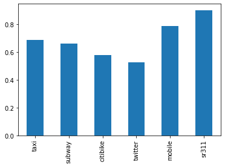

```python
res.R2.plot.bar()
```